# Отчёт по лабораторной работе №6

Адресация IPv4 и IPv6. Двойной стек

Чилеше Лупупа

Российский университет дружбы народов, Москва, Россия

16 декабря 2025

# Цель работы

## Цель лабораторной работы

Изучение принципов распределения и настройки адресного пространства  
в IPv4/IPv6 сетях, а также проверка работы сети с двойным стеком адресации.

# Разбиение IPv4-сети на подсети

## Сеть 172.16.20.0/24 (характеристики)

- Префикс: /24, маска: 255.255.255.0
- Сеть: 172.16.20.0, broadcast: 172.16.20.255
- Хосты: 172.16.20.1 – 172.16.20.254 (254 узла)

## Разбиение 172.16.20.0/24 на 126, 62, 62 (VLSM)

- 126 узлов → /25
- 62 узла → /26
- 62 узла → /26

| Подсеть | Префикс | Сеть | Broadcast | Диапазон хостов |
| --- | --- | --- | --- | --- |
| 1 | /25 | 172.16.20.0 | 172.16.20.127 | 172.16.20.1 – 172.16.20.126 |
| 2 | /26 | 172.16.20.128 | 172.16.20.191 | 172.16.20.129 – 172.16.20.190 |
| 3 | /26 | 172.16.20.192 | 172.16.20.255 | 172.16.20.193 – 172.16.20.254 |

## Сеть 10.10.1.64/26 и подсеть на 30 узлов

**Исходная сеть:** - /26, маска 255.255.255.192 - сеть 10.10.1.64, broadcast 10.10.1.127 - хосты 10.10.1.65 – 10.10.1.126 (62 узла)

**Подсеть на 30 узлов:** - /27, сеть 10.10.1.64/27 - broadcast 10.10.1.95 - хосты 10.10.1.65 – 10.10.1.94

## Сеть 10.10.1.0/26 и подсеть на 14 узлов

**Исходная сеть:** - /26, маска 255.255.255.192 - сеть 10.10.1.0, broadcast 10.10.1.63 - хосты 10.10.1.1 – 10.10.1.62 (62 узла)

**Подсеть на 14 узлов:** - /28, сеть 10.10.1.0/28 - broadcast 10.10.1.15 - хосты 10.10.1.1 – 10.10.1.14

# Разбиение IPv6-сети на подсети

## Сеть 2001:db8:c0de::/48

- Префикс: /48
- Маска: ffff:ffff:ffff::
- Диапазон (краевые значения):
  - min: 2001:db8:c0de:0000:0000:0000:0000:0000
  - max: 2001:db8:c0de:ffff:ffff:ffff:ffff:ffff

## 2001:db8:c0de::/48 → 2 подсети (по Subnet ID)

Разбиение по Subnet ID (добавляем 1 бит к префиксу):

- Подсеть A: 2001:db8:c0de:0000::/49
- Подсеть B: 2001:db8:c0de:8000::/49

Смысл: деление выполняется в области Subnet ID (четвёртый хекстет), сохраняя иерархию /48 как site prefix.

## 2001:db8:c0de::/48 → 2 подсети (по Interface ID)

Разбиение внутри host-части:

- Подсеть A: 2001:db8:c0de:0000::/65
- Подсеть B: 2001:db8:c0de:0000:8000::/65

Смысл: деление происходит в Interface ID (последние 64 бита). Практически используется редко из-за ожидания /64 (SLAAC).

## Сеть 2a02:6b8::/64 и разбиение на 2 подсети

- Префикс: /64
- Маска: ffff:ffff:ffff:ffff::
- Диапазон (краевые значения):
  - min: 2a02:6b8:0000:0000:0000:0000:0000:0000
  - max: 2a02:6b8:0000:0000:ffff:ffff:ffff:ffff

Разбиение на 2 подсети возможно только с изменением префикса (например /65), то есть фактически — по Interface ID: - 2a02:6b8::/65 - 2a02:6b8:0:0:8000::/65

# Адресация IPv4 и IPv6. Двойной стек

## Топология лабораторной работы в GNS3

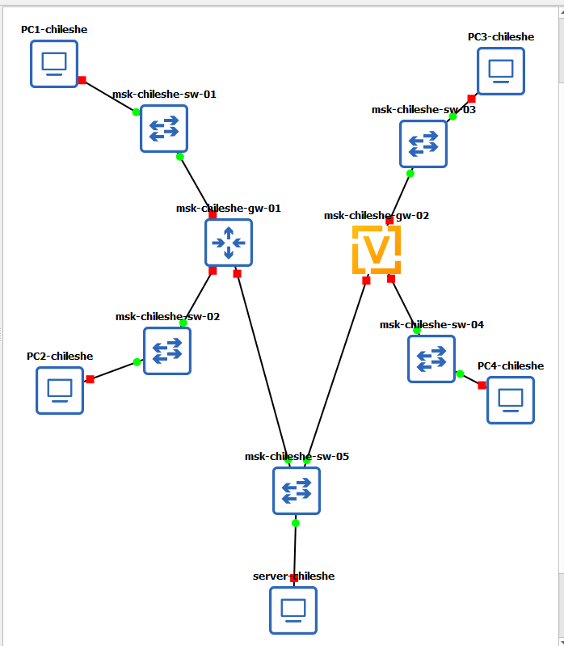

Топология сети с FRR и Dual Stack Server

## Настройка IPv4 на PC1

[figure not shown]

Настройка IPv4-адреса на PC1 и show ip

## Настройка IPv4 на PC2

[figure not shown]

Настройка IPv4-адреса на PC2 и show ip

## Настройка IPv4 на сервере (Dual Stack Server)

[figure not shown]

Настройка IPv4 на сервере и show ip

## Настройка IPv4 на маршрутизаторе FRR

[figure not shown]

Настройка интерфейсов FRR (eth0/eth1/eth2)

## Проверка конфигурации FRR

[figure not shown]

show running-config и show interface brief

## Проверка связности IPv4 (ping с сервера)

[figure not shown]

Ping до PC1 и PC2 с сервера

## Проверка маршрута IPv4 (trace с PC2)

[figure not shown]

Trace с PC2 до PC1 и сервера

## Настройка IPv6 на PC3

[figure not shown]

Настройка IPv6 на PC3 и show ipv6

## Настройка IPv6 на PC4

[figure not shown]

Настройка IPv6 на PC4 и show ipv6

## Проверка IPv4/IPv6 на сервере

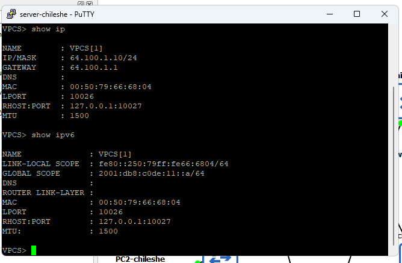

show ip и show ipv6 на сервере двойного стека

## Настройка IPv6 на VyOS (msk-chileshe-gw-02)

[figure not shown]

Назначение IPv6 адресов и Router Advertisement на VyOS

## Проверка интерфейсов VyOS

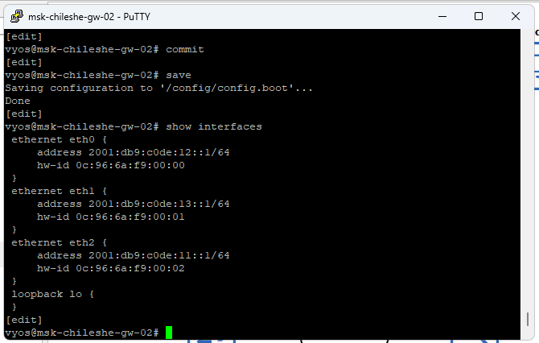

show interfaces на VyOS

## Проверка IPv6-связности и изоляции подсетей

[figure not shown]

[figure not shown]

## Изоляция IPv4 и IPv6 подсетей

[figure not shown]

# Анализ трафика (Wireshark)

## ARP: разрешение MAC по IPv4

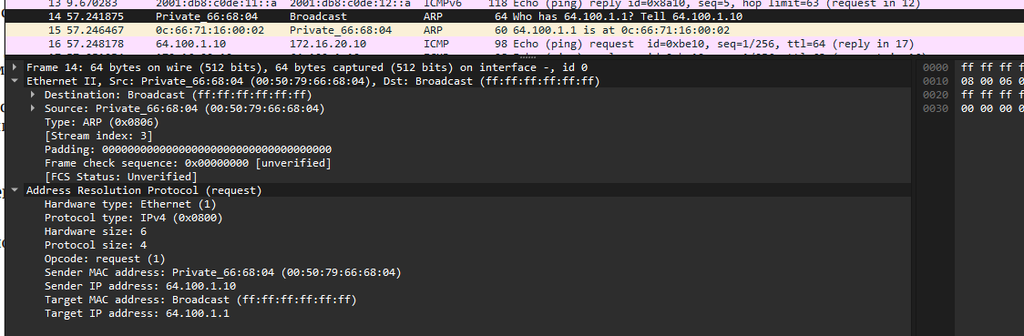

ARP-запрос к шлюзу 64.100.1.1

## ICMP: Echo request / reply (IPv4)

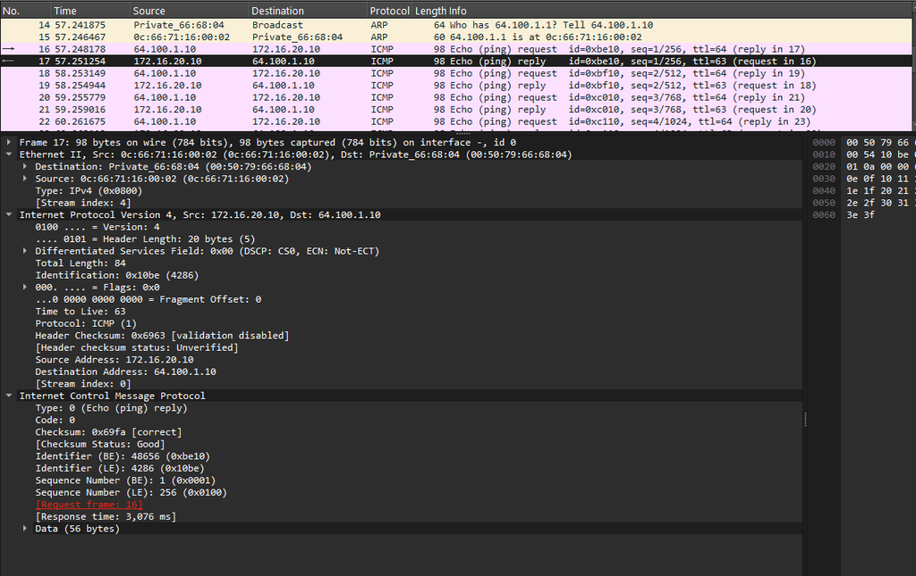

ICMP Echo reply и параметры пакета

## ICMPv6: Echo request / reply (IPv6)

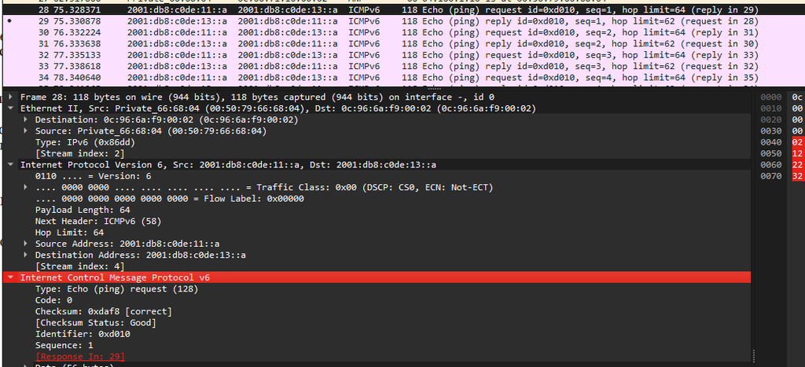

ICMPv6 Echo request и поля IPv6/ICMPv6

## Что извлекается из перехваченных пакетов

- **ARP:** соответствие IPv4 ↔︎ MAC, факт широковещательного запроса, MAC отправителя/цели
- **ICMP:** доступность узла, RTT, идентификатор/sequence, TTL (оценка пути)
- **ICMPv6:** доступность IPv6 узлов, Hop Limit, идентификатор/sequence, адреса источника/назначения

# Самостоятельное задание

## Топология с двумя локальными подсетями

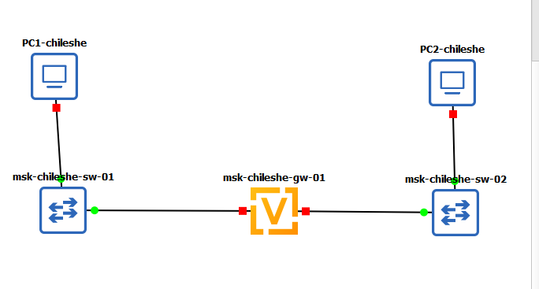

Топология самостоятельного задания

## Таблица адресации (минимальный адрес на интерфейсе маршрутизатора)

[output not shown]

## Проверка настроек PC1

[figure not shown]

show ip и show ipv6 на PC1

## Проверка настроек PC2

[figure not shown]

show ip и show ipv6 на PC2

## Настройка адресации на VyOS (gw-01)

[figure not shown]

Настройка IPv4/IPv6 и RA на VyOS

## Проверка интерфейсов VyOS

[figure not shown]

show interfaces (адреса на eth0/eth1)

## Проверка связности (ping)

[figure not shown]

Ping по IPv4 и IPv6 между подсетями

## Проверка маршрута (trace)

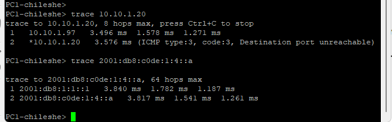

Trace по IPv4 и IPv6

# Вывод

## Итоги работы

- Выполнено разбиение адресного пространства **IPv4 (VLSM)** и **IPv6**
- Настроена сеть в GNS3 с **FRR (IPv4)** и **VyOS (IPv6)**
- Подтверждена работа **Dual Stack** и изоляция подсетей IPv4/IPv6
- Проанализирован трафик **ARP, ICMP, ICMPv6** в Wireshark